# Métodos multivariados - Tarea 3

## Problema 3

Para el conjunto de datos iris utilice análisis de clúster jerárquico.

```r
data <-scale(iris[,1:4])
data_d <- dist(data,method = "euclidean")
```

- Encuentre el dendograma con el método Single.

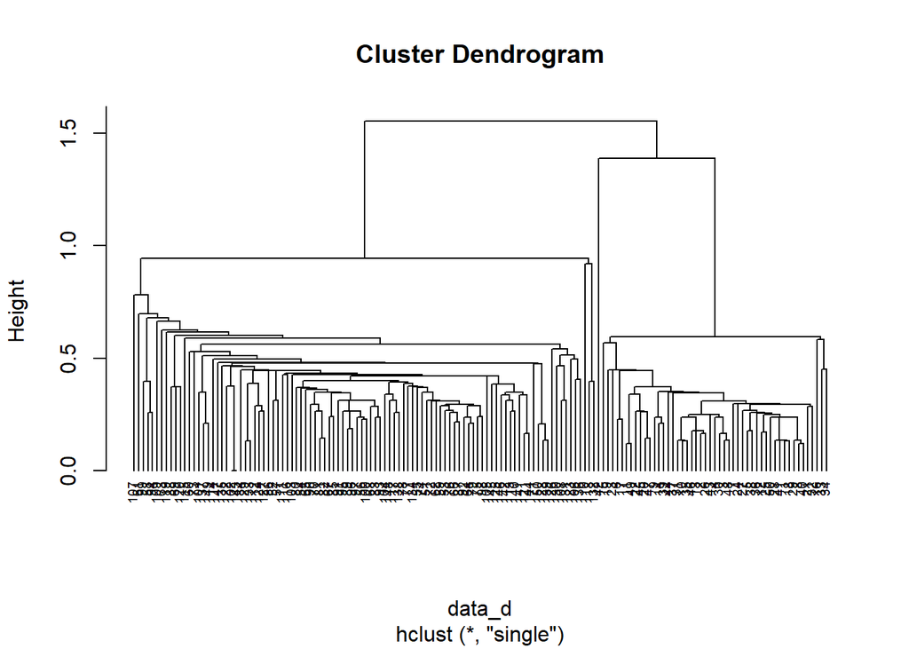

```r
clust1 <-hclust(data_d,method = "single")
plot(clust1, hang = -0.01, cex = 0.6)
```

- Dibuje el dendograma con el método complete.

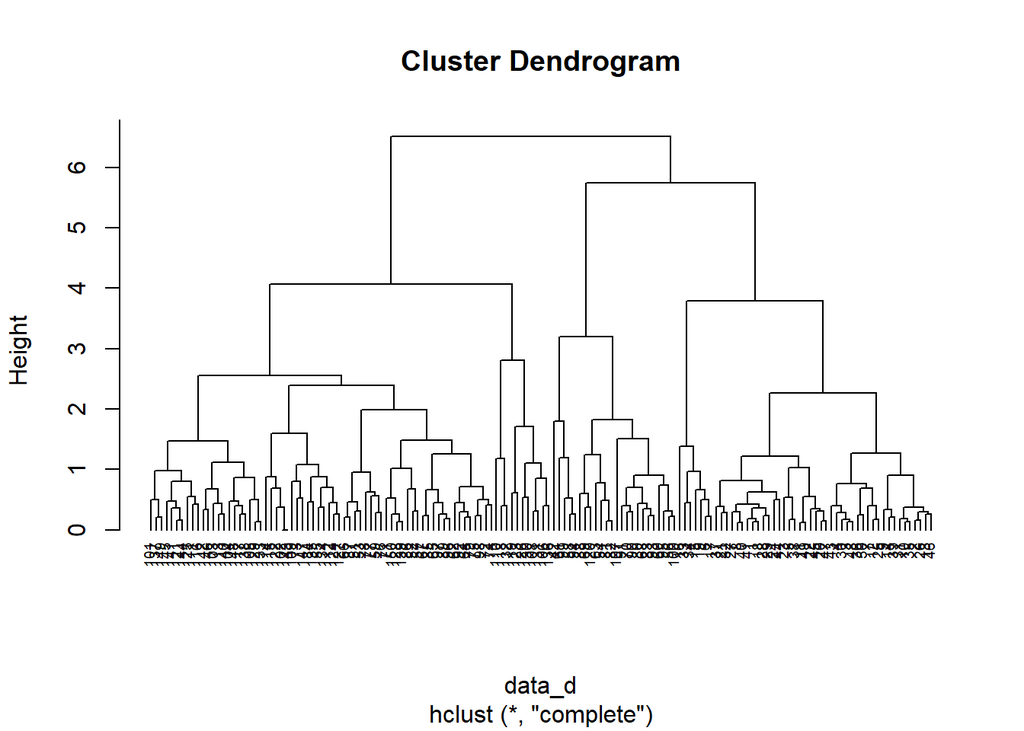

```r
clust1 <-hclust(data_d,method = "complete")
plot(clust1, hang = -0.01, cex = 0.6)
```

Para los siguientes incisos utilice el conjunto de datos position (posiciones iniciales de jugadores de futbol con 6 integrantes para cada equipo).

```r
position <- read.csv("../Data/position.csv")
position <- position[,2:3]
position
```

```
##      x   y
## 1   -1   1
## 2   -2  -3
## 3    8   6
## 4    7  -8
## 5  -12   8
## 6  -15   0
## 7  -13 -10
## 8   15  16
## 9   21   2
## 10  12 -15
## 11 -25   1
## 12  26   0
```

- Grafique las posiciones de los jugadores.

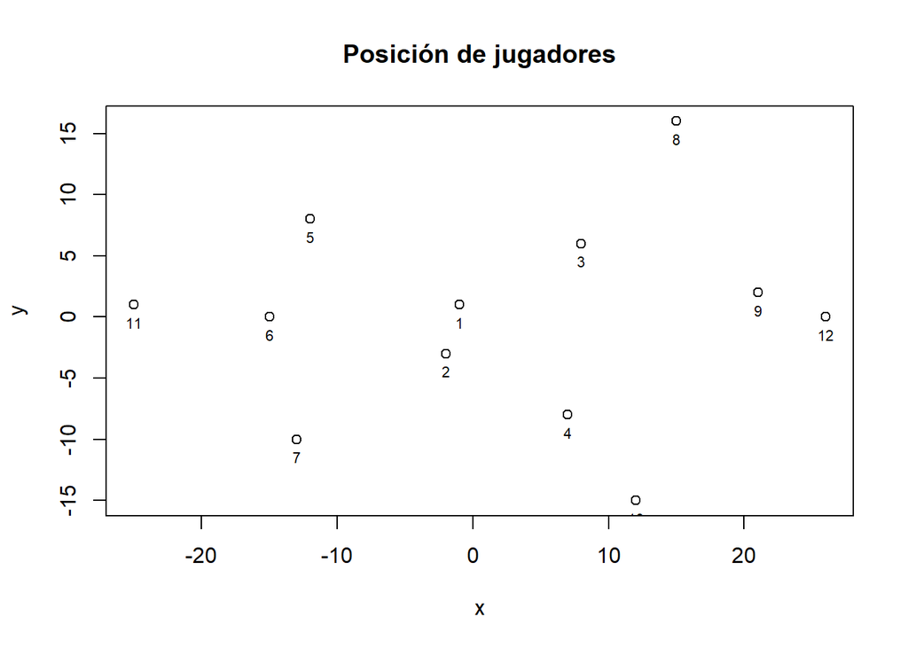

```r
plot(position, main = 'Posición de jugadores')
labels <- 1:12
text(position$x, position$y, labels, cex = 0.7, pos = 1)
```

- Aplique un análisis de clúster jerárquico con el método complete, corte el árbol con k= 3 y con k=4.

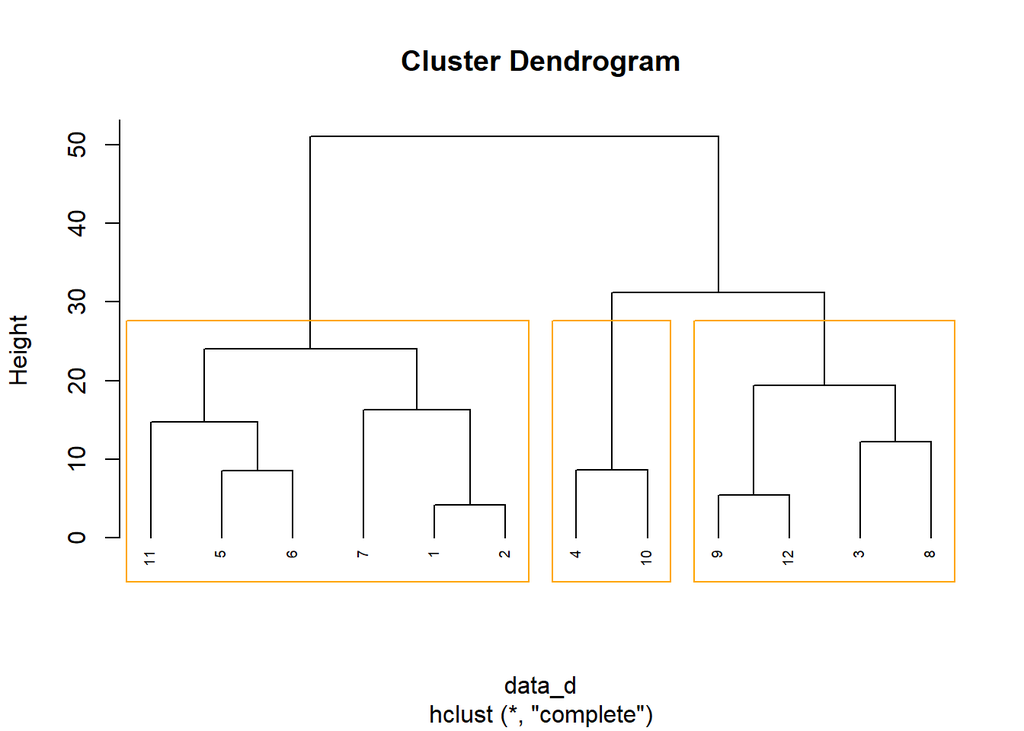

```r
data_d <- dist(position, method = "euclidean")

# k = 3
clust3 <-hclust(data_d, method = "complete")
plot(clust3, hang = -0.01, cex = 0.6)
rect.hclust(clust3, k=3, border = "orange")
```

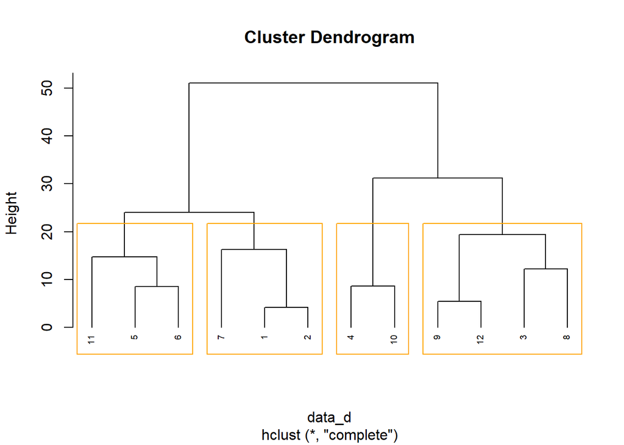

```r
# k = 4
clust4 <-hclust(data_d, method = "complete")
plot(clust4, hang = -0.01, cex = 0.6)
rect.hclust(clust4, k=4, border = "orange")
```

- Agregue al conjunto de datos una columna con el número de cluster al que pertenece.

```r
df_analisis <- function(k, m, ajuste) {
  matriz <- matrix(data = 1:3, nrow = 1, ncol = 3)
  fila <- 1
  for (i in 1:k) {
    for (elemento in rownames(m)[ajuste==i]) {
      matriz <- rbind(matriz, c(m[fila,1], m[fila,2], i))
      fila <- fila + 1
    }
  }

  colnames(matriz) <- c("x", "y", "Cluster")
  matriz <- matriz[2:13, ]
  matriz
}

# k = 3
ajuste3 <- cutree(clust3, k = 3)
table(ajuste3)
```

```
## ajuste3
## 1 2 3
## 6 4 2
```

```r
print(rownames(position)[ajuste3==1])
```

```
## [1] "1"  "2"  "5"  "6"  "7"  "11"
```

```r
print(rownames(position)[ajuste3==2])
```

```
## [1] "3"  "8"  "9"  "12"
```

```r
print(rownames(position)[ajuste3==3])
```

```
## [1] "4"  "10"
```

```r
df_analisis3 <- df_analisis(3, position, ajuste3)
df_analisis3
```

```
##         x   y Cluster
##  [1,]  -1   1       1
##  [2,]  -2  -3       1
##  [3,]   8   6       1
##  [4,]   7  -8       1
##  [5,] -12   8       1
##  [6,] -15   0       1
##  [7,] -13 -10       2
##  [8,]  15  16       2
##  [9,]  21   2       2
## [10,]  12 -15       2
## [11,] -25   1       3
## [12,]  26   0       3
```

```r
# k = 4
ajuste4 <- cutree(clust3, k = 4)
table(ajuste4)
```

```
## ajuste4
## 1 2 3 4
## 3 4 2 3
```

```r
print(rownames(position)[ajuste4==1])
```

```
## [1] "1" "2" "7"
```

```r
print(rownames(position)[ajuste4==2])
```

```
## [1] "3"  "8"  "9"  "12"
```

```r
print(rownames(position)[ajuste4==3])
```

```
## [1] "4"  "10"
```

```r
print(rownames(position)[ajuste4==4])
```

```
## [1] "5"  "6"  "11"
```

```r
df_analisis4 <- df_analisis(4, position, ajuste4)
df_analisis4
```

```
##         x   y Cluster
##  [1,]  -1   1       1
##  [2,]  -2  -3       1
##  [3,]   8   6       1
##  [4,]   7  -8       2
##  [5,] -12   8       2
##  [6,] -15   0       2
##  [7,] -13 -10       2
##  [8,]  15  16       3
##  [9,]  21   2       3
## [10,]  12 -15       4
## [11,] -25   1       4
## [12,]  26   0       4
```

- Grafique las posiciones agregando color para la variable cluster.

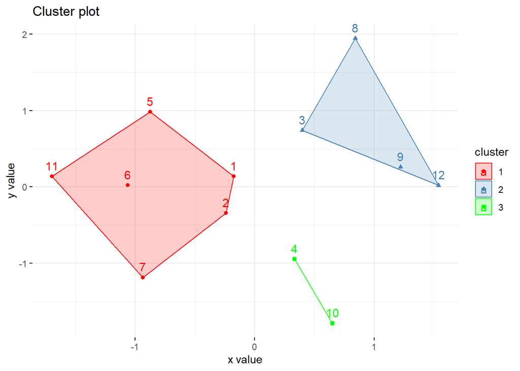

```r
# k = 3
fviz_cluster(list(data = position, cluster = ajuste3), palette = c("red", "steelblue", "green"),
             ellipse.type = "convex",
             show.clust.cent = FALSE,
             ggtheme = theme_minimal())
```

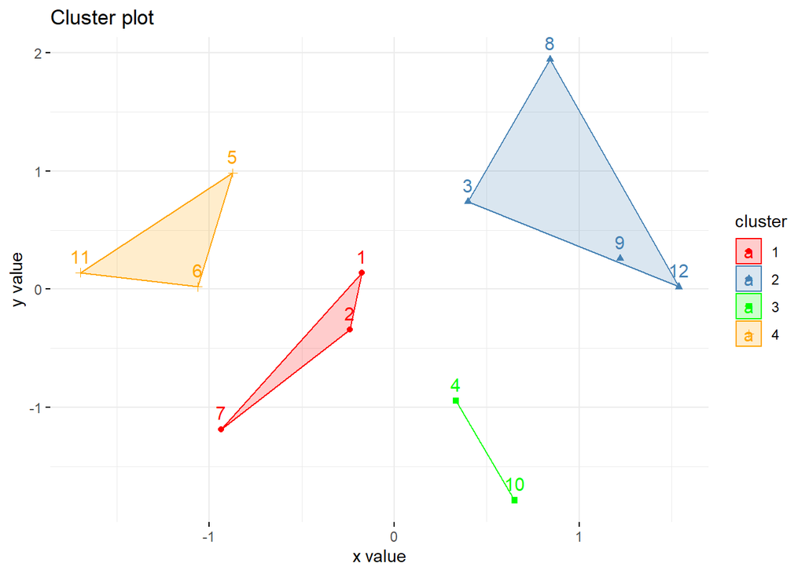

```r
# k = 4
fviz_cluster(list(data = position, cluster = ajuste4), palette = c("red", "steelblue", "green", "orange"),
             ellipse.type = "convex",
             show.clust.cent = FALSE,
             ggtheme = theme_minimal())
```

- Repita con k=2 y el método War.

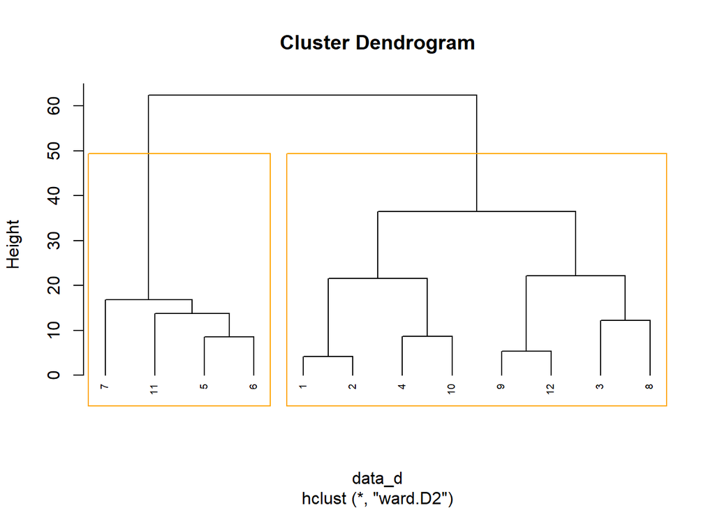

```r
clust3 <-hclust(data_d, method = "ward.D2")
plot(clust3, hang = -0.01, cex=0.6)
rect.hclust(clust3, k = 2, border = "orange")
```

- Repita con K=2 y el método kmeans.

```r
kposition <- position

df_d <- dist(kposition)
set.seed(2)
km_p <- kmeans(df_d,nstart = 25,centers = 2)
rownames(kposition)[km_p$cluster==1]
```

```
## [1] "3"  "4"  "8"  "9"  "10" "12"
```

```r
rownames(kposition)[km_p$cluster==2]
```

```
## [1] "1"  "2"  "5"  "6"  "7"  "11"
```

```r
cluster = km_p$cluster
head(cbind(kposition, cluster))
```

```
##     x  y cluster
## 1  -1  1       2
## 2  -2 -3       2
## 3   8  6       1
## 4   7 -8       1
## 5 -12  8       2
## 6 -15  0       2
```

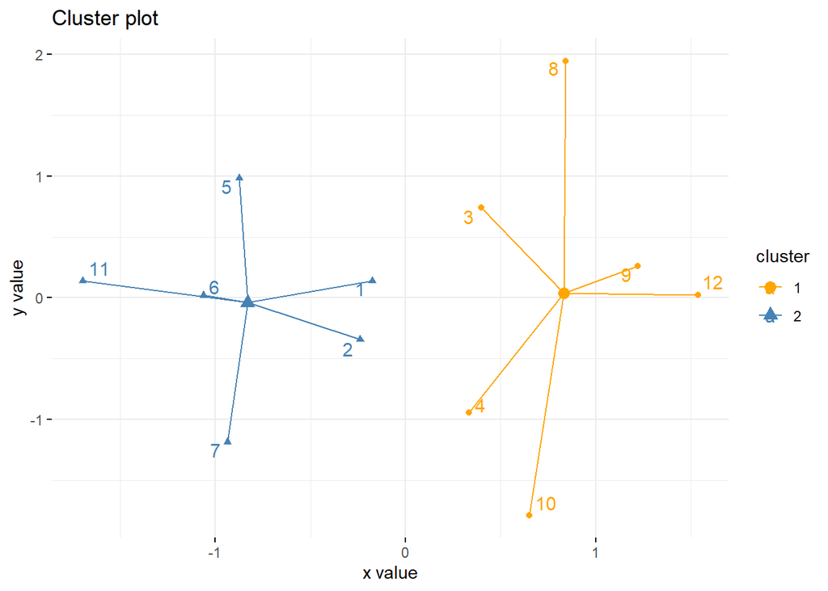

```r
fviz_cluster(km_p, data = kposition,  palette=c("orange", "steelblue"),
             star.plot = TRUE,ellipse.type = "eclid",
             repel=T,
             ggtheme = theme_minimal())
```